# First Order Vector Autoregression

Benjamin Christoffersen

2019-06-20

## Introduction

We will simulate and estimate a first order vector auto-regression model in this example using the particle filter and smoother. For details see this vignette which can also be found by calling `vignette("Particle_filtering", package = "dynamichazard")`. The models we are going to simulate from and estimate are of the form

$$\begin{split}
y_{it} &\sim g(\cdot\vert\eta_{it}) & \\
\vec{\eta}_t &= X_tR^+\vec{\alpha}_t + Z_t\vec{\beta} + \vec{o}_t \\
\vec{\alpha}_t &= F\vec{\alpha}_{t - 1} + R\vec{\epsilon}_t &
\quad \vec{\epsilon}_t \sim N(\vec{0}, Q) \\
& & \quad \vec{\alpha}_0 \sim N(\vec{a}_0, Q_0)
\end{split}, \qquad
\begin{array}{l} i = 1, \dots, n_t \\ t = 1, \dots, d \end{array}$$

where the $y_{it}$ is individual $i$’s indicator at time $t$ for whether he dies between time $(t - 1, t]$. The indicators, $y_{it}$, are binomial distributed with the complementary log-log link function conditional on knowing the log times at risk, $\vec{o}_1,\cdots,\vec{o}_d$, covariates, $X_t$ and $Z_t$, and latent states, $\vec{\alpha}_1,\dots,\vec{\alpha}_d$. The total survival time of individual $i$ is $T_i$ which is piecewise constant exponentially distributed conditional on knowing the latent states. Further, we set $Z_t = X_t$ so the states have a non-zero mean. The true values are

$$F = \begin{pmatrix}0.9 & 0 \\ 0 & 0.9 \end{pmatrix}, \quad
Q = \begin{pmatrix}0.33^2 & 0 \\ 0 & 0.33^2 \end{pmatrix}, \quad
R = I_2, \quad
\vec{\beta} = (-6.5, -2)^\top$$

where $I_2$ is the two-dimensional identity matrix and $\vec{a}_0$ and $Q_0$ are given by the invariant distribution. The unknown parameters to be estimated is everything but $Q_0$ and $R$ (since we fix $Q_0$ doing the estimation and we set $\vec{a}_0 = (0, 0)^\top$). This example is run on the git branch “master” with ID “30bc39b”. The code can be found on [the github site for the package](https://github.com/boennecd/dynamichazard/tree/master/examples). All functions which assignments are not shown and are not in the `dynamichazard` package can be found on the github site.

## Simulation

We start by simulating the data. Feel free to skip this part as the specifications are given above. First we assign the parameters for the simulation

```r
library(dynamichazard)
n_obs     <- 1000L
n_periods <- 200L

Fmat <- matrix(c(.9, 0, 0, .9), 2)
Rmat <- diag(1    , 2)
Qmat <- diag(.33^2, 2)
Q_0  <- get_Q_0(Qmat, Fmat)
beta <- c(-6.5, -2)
```

`get_Q_0` is a function to get the covariance matrix for the invariant distribution. Then we simulate and plot the latent states

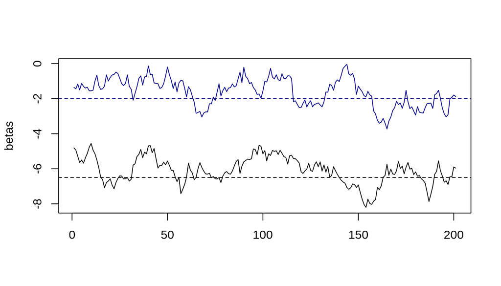

```r
set.seed(54432125)
betas <- matrix(nrow = n_periods + 1, ncol = 2)
betas[1, ] <- rnorm(2) %*% chol(Q_0)
for(i in 1:n_periods + 1)
  betas[i, ] <- Fmat %*% betas[i - 1, ] + drop(rnorm(2) %*% chol(Qmat))

betas <- t(t(betas) + beta)

# plot of latent variables
cols <- c("black", "darkblue")
matplot(betas, type = "l", lty = 1, col = cols)
for(i in 1:2)
  abline(h = beta[i], lty = 2, col = cols[i])
```

We simulate the observations as follows

```r
df <- replicate(n_obs, {
  # left-censoring
  tstart <- max(0L, sample.int((n_periods - 1L) * 2L, 1) - n_periods + 1L)

  # covariates
  x <- runif(1, -1, 1)
  covars <- c(1, x)

  # outcome (stop time and event indicator)
  y <- FALSE
  for(tstop in (tstart + 1L):n_periods){
    fail_time <- rexp(1) / exp(covars %*% betas[tstop + 1L, ])
    if(fail_time <= 1){
      y <- TRUE
      tstop <- tstop - 1L + fail_time
      break
    }
  }

  c(tstart = tstart, tstop = tstop, x = x, y = y)
})
df <- data.frame(t(df))
head(df, 10)
```

```
##    tstart  tstop        x y
## 1       0 200.00  0.12579 0
## 2      69 200.00 -0.33636 0
## 3       0 200.00  0.09738 0
## 4       0 200.00  0.29843 0
## 5       0 200.00 -0.58910 0
## 6     115 200.00  0.15406 0
## 7       6  41.03 -0.44064 1
## 8       0 174.63 -0.51311 1
## 9      70 200.00  0.93480 0
## 10     34 200.00 -0.07022 0
```

We left-censor the observations since we otherwise may end up with a low number of observations towards the end.

### Model without latent variables

We can fit a model without the latent variables (i.e., a constant coefficient model) as follows

```r
surv_fit <- survreg(Surv(tstop - tstart, y) ~ x, df, dist = "exponential")
summary(surv_fit) # signs are flipped
```

```
##
## Call:
## survreg(formula = Surv(tstop - tstart, y) ~ x, data = df, dist = "exponential")
##              Value Std. Error    z      p
## (Intercept) 5.7498     0.0584 98.4 <2e-16
## x           1.3555     0.0990 13.7 <2e-16
##
## Scale fixed at 1
##
## Exponential distribution
## Loglik(model)= -2477   Loglik(intercept only)= -2581
##  Chisq= 207.8 on 1 degrees of freedom, p= 4.2e-47
## Number of Newton-Raphson Iterations: 5
## n= 1000
```

```r
logLik(surv_fit)
```

```
## 'log Lik.' -2477 (df=2)
```

The signs are flipped as stated in `help("survreg")`. They are though close to $\vec{\beta}$ as expected. Further, we can compare the log-likelihood with this models with the log-likelihood approximation we get from the particle filter in the next section.

## Particle filter and smoother

We start off by using the generalized two-filter smoother from Briers, Doucet, and Maskell (2009). We estimate the parameters with an EM algorithm by calling `PF_EM` as follows

```r
n_threads <- 6

# you can replace this with e.g.,
# max(parallel::detectCores(logical = FALSE), 2)))
```

```r
set.seed(30520116)
system.time(pf_Brier <- PF_EM(
  Surv(tstart, tstop, y) ~ x + ddFixed(x) + ddFixed_intercept(TRUE), df,
  Q_0 = diag(1, 2), Q = diag(1, 2), Fmat = matrix(c(.1, 0, 0, .1), 2),
  by = 1, type = "VAR", model = "exponential", max_T = n_periods,
  control = PF_control(
    N_fw_n_bw = 750, N_smooth = 1, N_first = 2000, eps = .001,
    method = "AUX_normal_approx_w_cloud_mean", fix_seed = FALSE,
    n_max = 100, smoother = "Brier_O_N_square",
    # we add some extra variation to the proposal distributions
    nu = 8, covar_fac = 1.1, n_threads = n_threads)))
```

```
## a_0 not supplied. IWLS estimates of static glm model is used for random walk models. Otherwise the values are zero
```

```
##    user  system elapsed
##  7038.2   118.8  1266.3
```

`system.time` is used to show the computation time. The estimated parameters are

```r
pf_Brier$F
```

```
##             (Intercept)        x
## (Intercept)     0.91704 0.004692
## x               0.09276 0.901095
```

```r
show_covar <- function(Q){
  cat("Standard deviations\n")
  print(sqrt(diag(Q)))
  cat("Lower correlation matrix\n")
  tmp <- cov2cor(Q)
  print(tmp[-1, -ncol(tmp)])
}
show_covar(pf_Brier$Q)
```

```
## Standard deviations
## (Intercept)           x
##      0.3085      0.3249
## Lower correlation matrix
## [1] -0.2651
```

```r
pf_Brier$fixed_effects
```

```
## (Intercept)  ddFixed(x)
##      -6.082      -1.458
```

The effective sample size in the smoothing step at each time point is

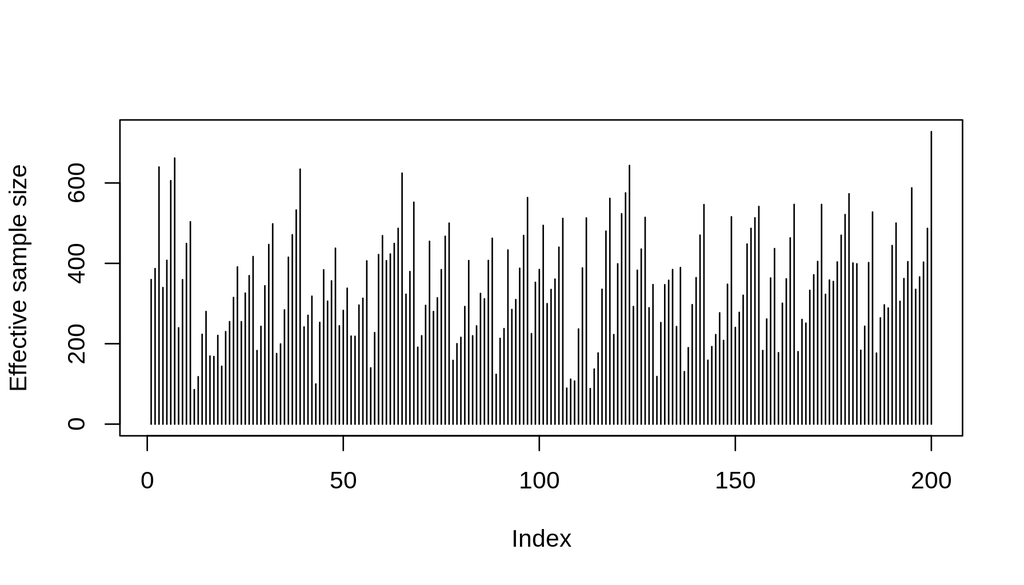

```r
plot(pf_Brier$effective_sample_size$smoothed_clouds, type = "h",
     ylim = range(0, pf_Brier$effective_sample_size$smoothed_clouds),
     ylab = "Effective sample size")
```

The smoothed estimates of the latent states looks as follows (the vertical dashed lines are points where we did not sample well)

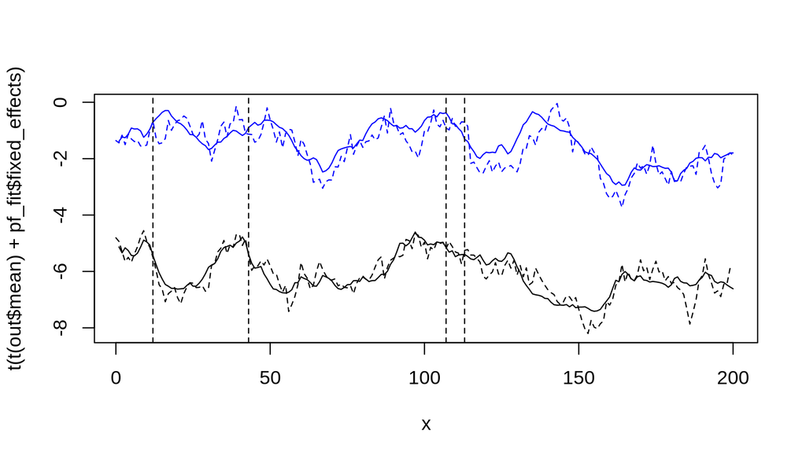

```r
plot_cloud(pf_Brier)
```

The dashed non-vertical lines are the true curve and the continuous is the smoothed estimate. The approximate log-likelihoods from the particle filter at each EM iteration are

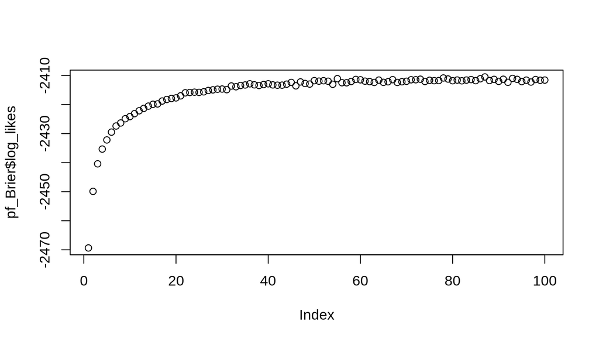

```r
plot(pf_Brier$log_likes)
```

We can compare the output above with the smoother from Fearnhead, Wyncoll, and Tawn (2010)

```r
set.seed(30520116)
system.time(pf_Fear <- PF_EM(
  Surv(tstart, tstop, y) ~ x + ddFixed(x) + ddFixed_intercept(TRUE), df,
  Q_0 = diag(1, 2), Q = diag(1, 2), Fmat = matrix(c(.1, 0, 0, .1), 2),
  by = 1, type = "VAR", model = "exponential", max_T = n_periods,
  control = PF_control(
    N_fw_n_bw = 1000, N_smooth = 2000, N_first = 2000, eps = .001,
    method = "AUX_normal_approx_w_cloud_mean", fix_seed = FALSE,
    n_max = 100, smoother = "Fearnhead_O_N",
    nu = 8, covar_fac = 1.1, n_threads = n_threads)))
```

```
## a_0 not supplied. IWLS estimates of static glm model is used for random walk models. Otherwise the values are zero
```

```
##    user  system elapsed
## 3751.36   41.92  645.82
```

The estimates are similar

```r
pf_Fear$F
```

```
##             (Intercept)        x
## (Intercept)      0.9164 0.006058
## x                0.0980 0.894634
```

```r
show_covar(pf_Fear$Q)
```

```
## Standard deviations
## (Intercept)           x
##       0.306       0.327
## Lower correlation matrix
## [1] -0.265
```

```r
pf_Fear$fixed_effects
```

```
## (Intercept)  ddFixed(x)
##      -6.081      -1.473
```

The effective sample size are better now though

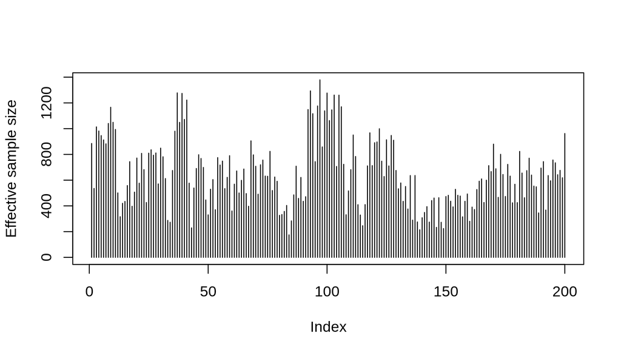

```r
plot(pf_Fear$effective_sample_size$smoothed_clouds, type = "h",
     ylim = range(0, pf_Fear$effective_sample_size$smoothed_clouds),
     ylab = "Effective sample size")
```

However, there are many options to reduce the computation time for the former smoother as e.g, mentioned in Briers, Doucet, and Maskell (2009) but those are not implemented. The smoothed estimates are also rather close to what we saw before

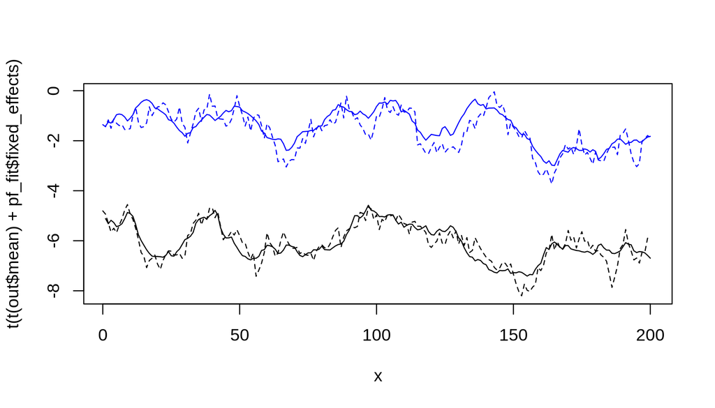

```r
plot_cloud(pf_Fear)
```

The log-likelihoods are almost the same

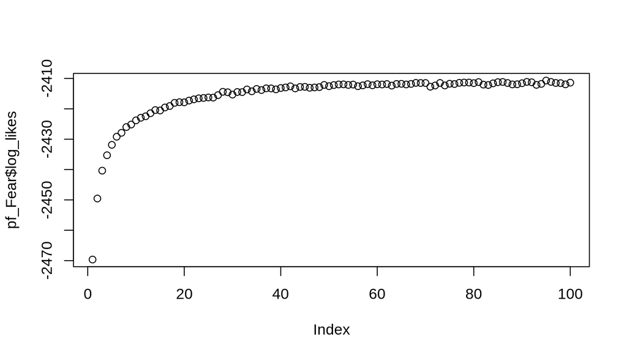

```r
plot(pf_Fear$log_likes)
```

The log-likelihood where flat toward the end and not monotonically increasing

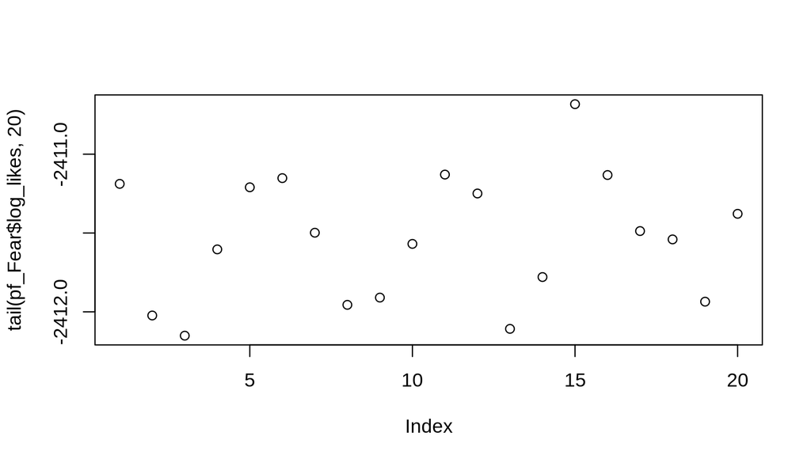

```r
plot(tail(pf_Fear$log_likes, 20))
```

This will not happen in an EM algorithm but may happen in an MCEM algorithm due to the Monte Carlo error. We may want to take a few more EM iterations with more particles. We can do this as follows

```r
set.seed(30520116)
pf_Fear_more <- PF_EM(
  Surv(tstart, tstop, y) ~ x + ddFixed(x) + ddFixed_intercept(TRUE), df,
  Q_0 = diag(1, 2), Q = pf_Fear$Q, Fmat = pf_Fear$F,
  fixed_effects = pf_Fear$fixed_effects, by = 1, type = "VAR",
  model = "exponential", max_T = n_periods,
  control = PF_control(
    N_fw_n_bw = 5000, N_smooth = 10000, N_first = 5000, eps = .001,
    method = "AUX_normal_approx_w_cloud_mean", fix_seed = FALSE,
    n_max = 10, smoother = "Fearnhead_O_N",
    nu = 8, covar_fac = 1.1, n_threads = n_threads))
```

```
## a_0 not supplied. IWLS estimates of static glm model is used for random walk models. Otherwise the values are zero
```

The log-likelihoods from these iterations are

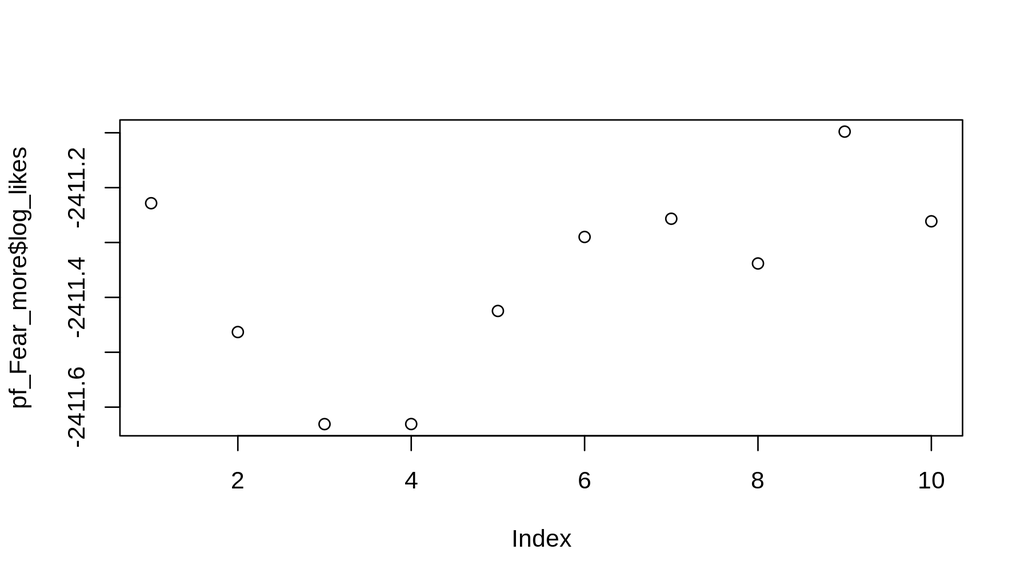

```r
plot(pf_Fear_more$log_likes)
```

and the final estimates are

```r
pf_Fear_more$F
```

```
##             (Intercept)        x
## (Intercept)     0.91549 0.005127
## x               0.09387 0.895233
```

```r
show_covar(pf_Fear_more$Q)
```

```
## Standard deviations
## (Intercept)           x
##      0.3044      0.3200
## Lower correlation matrix
## [1] -0.2809
```

```r
pf_Fear_more$fixed_effects
```

```
## (Intercept)  ddFixed(x)
##      -6.073      -1.465
```

### Averaging

Averaging is sometimes argued for in MCEM algorithm. E.g., see Cappé, Moulines, and Ryden (2005) section 11.1.2.2. The idea is to take an average the estimates or sufficient sufficient statistic after some iteration number. As of this writing, the present implementation does not allow one to change the number of particles at each iteration as suggested in Cappé, Moulines, and Ryden (2005).

```r
set.seed(30520116)
system.time(pf_Fear_avg <- PF_EM(
  Surv(tstart, tstop, y) ~ x + ddFixed(x) + ddFixed_intercept(TRUE), df,
  Q_0 = diag(1, 2), Q = diag(1, 2), Fmat = matrix(c(.1, 0, 0, .1), 2),
  by = 1, type = "VAR", model = "exponential", max_T = n_periods,
  control = PF_control(
    N_fw_n_bw = 200, N_smooth = 400, N_first = 1000, eps = 1e-5,
    method = "AUX_normal_approx_w_cloud_mean", fix_seed = FALSE,
    n_max = 1000L, smoother = "Fearnhead_O_N", averaging_start = 150L,
    nu = 8, covar_fac = 1.1, n_threads = n_threads)))
```

```
## a_0 not supplied. IWLS estimates of static glm model is used for random walk models. Otherwise the values are zero
```

```
##    user  system elapsed
## 6434.87   65.56 1108.72
```

```r
pf_Fear_avg$F
```

```
##             (Intercept)       x
## (Intercept)     0.90526 0.01128
## x               0.08947 0.89383
```

```r
show_covar(pf_Fear_avg$Q)
```

```
## Standard deviations
## (Intercept)           x
##      0.3203      0.3085
## Lower correlation matrix
## [1] -0.2563
```

```r
pf_Fear_avg$fixed_effects
```

```
## (Intercept)  ddFixed(x)
##      -6.046      -1.435
```

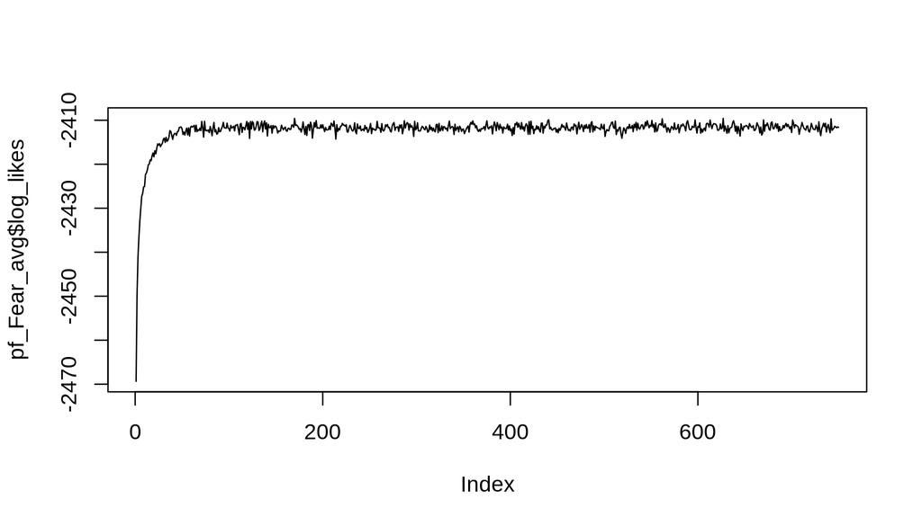

```r
plot(pf_Fear_avg$log_likes, type = "l")
```

### Stochastic gradient descent

We will run stochastic gradient descent as in Polyak and Juditsky (1992) which is described in Cappé, Moulines, and Ryden (2005, 414).

```r
#####
# fit to start from
set.seed(30520116)
pf_start <- PF_EM(
  Surv(tstart, tstop, y) ~ x + ddFixed(x) + ddFixed_intercept(TRUE), df,
  Q_0 = diag(1, 2), Q = diag(1, 2), Fmat = matrix(c(.1, 0, 0, .1), 2),
  by = 1, type = "VAR", model = "exponential", max_T = n_periods,
  control = PF_control(
    N_fw_n_bw = 200, N_smooth = 400, N_first = 1000, eps = 1e-5,
    method = "AUX_normal_approx_w_cloud_mean", fix_seed = FALSE,
    n_max = 1L, smoother = "Fearnhead_O_N",
    nu = 8, covar_fac = 1.1, n_threads = n_threads))
```

```
## a_0 not supplied. IWLS estimates of static glm model is used for random walk models. Otherwise the values are zero
```

```r
# Function to perform stochastic gradient descent. Uses Adam algorithm
# suggested by Kingma et al. (2015).
#
# Args:
#   object: an object of class PF_EM.
#   n_runs: number of iterations.
#   ns: number of particles at each iteration.
#   debug: TRUE if information should be printed during estimation.
#   use_O_n_sq: TRUE if O(N^2) method should be used.
#   lr: learning rate.
#   mp: decay rate for first moment.
#   vp: decay rate for second moment.
#
# Returns:
#   list with final estimates, log-likelihood approximations at each iteration,
#   and estimates at each iteration.
sgd <- function(object, n_runs, ns, debug = FALSE, use_O_n_sq = FALSE,
                lr = .001, mp = .9, vp = .999)
{
  #####
  # get object to perform computation and matrices and vectors for output
  comp_obj <- PF_get_score_n_hess(object, use_O_n_sq = use_O_n_sq)
  state <- matrix(
    NA_real_, n_runs + 1L, length(object$F) + length(object$Q))

  # setup matrix to map from gradient to the state (the covariance part is only
  # the lower diagonal)
  dF <- length(object$F)
  dQ <- NCOL(object$Q)
  nQ <- (dQ * (dQ + 1L)) / 2L
  K <- matrix(0., ncol(state), length(object$F) + nQ)
  K[  1:dF ,   1:dF] <- diag(dF)
  # can use e.g., matrixcal instead to get the duplication matrix
  K[-(1:dF), -(1:dF)] <- dynamichazard:::.get_dup_mat(dQ)

  dfix <- length(object$fixed_effects)
  obs   <- matrix(
    NA_real_, n_runs + 1L, dfix)
  state[1, ] <- c(object$F, object$Q)
  obs  [1, ] <- object$fixed_effects
  lls <- rep(NA_real_, n_runs)

  mv <- vv <- rep(0., ncol(K) + dfix)

  for(i in 1:n_runs){
    comp_obj$set_n_particles(N_fw = ns[i], N_first = ns[i])
    fw <- comp_obj$run_particle_filter()
    lls[i] <- logLik(fw)
    score <- comp_obj$get_get_score_n_hess(only_score = TRUE)
    sc <- score$score

    mv <- mp * mv + (1 - mp) * sc
    vv <- vp * vv + (1 - vp) * sc^2
    muse <- mv / (1 - mp^i)
    vuse <- vv / (1 - vp^i)
    direc <- muse / (sqrt(vuse) + 1e-8)

    # step-half until we have a valid set a of parameters
    n_halfs <- 0L
    n_halfs_max <- 25L
    lri <- lr
    while((n_halfs <- n_halfs + 1L) <= n_halfs_max){
      state_i <-
        state[i + 1L, ]  <- state[i, ]  + lri * drop(K %*% direc[-(1:dfix)])
      obs_i   <-
        obs  [i + 1L, ]  <- obs  [i, ]  + lri * direc[1:dfix]
      lri <- lri / 2

      # check that system is stationary
      Ftmp <- matrix(state_i[1:dQ^2], dQ, dQ)
      if(any(Mod(eigen(Ftmp)$values) >= 1))
        next

      # set parameters
      o <- comp_obj$set_parameters(state = state_i, obs = obs_i)

      # Q is positive definite
      if(all(eigen(o$Q)$values > 0.))
        break
    }

    if(n_halfs > n_halfs_max)
      stop("step halvings failed")

    if(debug){
      msg <- paste0(sprintf("It %4d Log-likelihood %10.2f (max %10.2f)", i,
                            lls[i], max(lls, na.rm = TRUE)))
      cat(msg, "\n", rep("-", nchar(msg)), "\n", sep = "")
      cat(sprintf("Gradient norm %14.4f\n", norm(t(sc))))
      print(o$Fmat)
      print(o$Q)
      print(o$fixed_effects)
      cat("\n")
    }
  }

  list(o = o, lls = lls, state = state, obs = obs)
}

# number of iterations
n_runs <- 400L
# number of particles to use
ns <- ceiling(exp(seq(log(100), log(1000), length.out = n_runs)))

out <- sgd(n_runs = n_runs, ns = ns, object = pf_start, lr = .005)
```

```
## Using 'df' as the 'data' argument
```

```r
lls <- out$lls
o <- out$o
```

The results are illustrated below

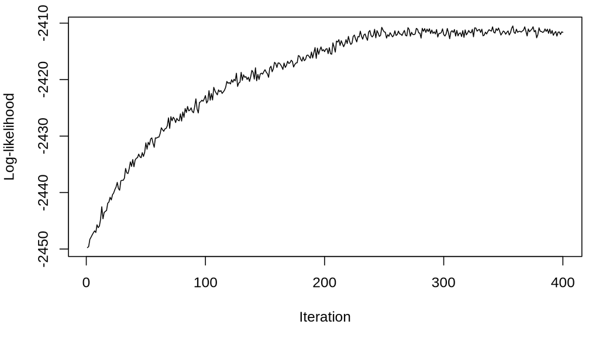

```r
# approximate log-likelihood at each iteration
par(mar = c(5, 4, 1, 1))
plot(lls, xlab = "Iteration", ylab = "Log-likelihood", type = "l")
```

```r
print(max(lls), digits = 5)
```

```
## [1] -2410.5
```

```r
# the estimates
o$Fmat
```

```
##             (Intercept)       x
## (Intercept)     0.90691 0.00592
## x               0.07199 0.89363
```

```r
show_covar(o$Q)
```

```
## Standard deviations
## (Intercept)           x
##      0.3215      0.3273
## Lower correlation matrix
## [1] -0.1338
```

```r
o$fixed_effects
```

```
## (Intercept)  ddFixed(x)
##      -6.154      -1.486
```

We can also use the method from Poyiadjis, Doucet, and Singh (2011). The present implementation scales poorly in the number of particles but the method has a variance that may be linear in the number of time periods instead of at least quadratic. This is important for long time series.

```r
# number of iterations
n_runs <- 400L
# number of particles to use
ns <- ceiling(exp(seq(log(200), log(1000), length.out = n_runs)))

out <- sgd(n_runs = n_runs, ns = ns, use_O_n_sq = TRUE,  object = pf_start,
           lr = .005)
```

```
## Using 'df' as the 'data' argument
```

```r
lls <- out$lls
o <- out$o
```

The results are illustrated below (the log-likelihood approximations from the forward particle filter are poor approximations due to few particles).

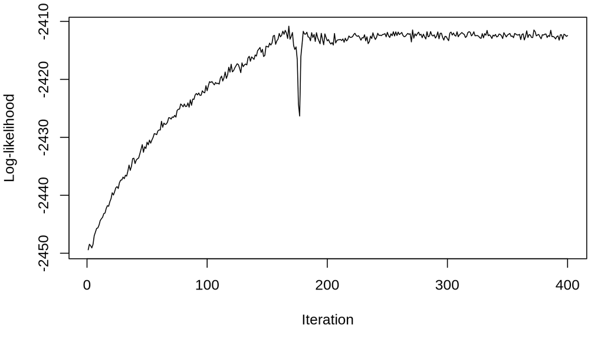

```r
# approximate log-likelihood at each iteration
par(mar = c(5, 4, 1, 1))
plot(lls, xlab = "Iteration", ylab = "Log-likelihood", type = "l")
```

```r
print(max(lls), digits = 5)
```

```
## [1] -2410.8
```

```r
# the estimates
o$Fmat
```

```
##             (Intercept)        x
## (Intercept)     0.88497 0.007784
## x               0.07199 0.859568
```

```r
show_covar(o$Q)
```

```
## Standard deviations
## (Intercept)           x
##      0.3658      0.3838
## Lower correlation matrix
## [1] -0.07005
```

```r
o$fixed_effects
```

```
## (Intercept)  ddFixed(x)
##      -6.127      -1.461
```

### Log-likelihood evaluation

We may question what the log-likelihood is at the true parameters. We can use the `PF_forward_filter` function to perform approximate log-likelihood evaluation

```r
fw_precise <- PF_forward_filter(
  Surv(tstart, tstop, y) ~ x + ddFixed(x) + ddFixed_intercept(TRUE),
  N_fw = 100000, N_first = 100000, df, type = "VAR",
  model = "exponential", max_T = n_periods, by = 1,
  control = PF_control(
    N_fw_n_bw = 1, N_smooth = 1, N_first = 1,
    method = "AUX_normal_approx_w_cloud_mean",
    smoother = "Fearnhead_O_N",
    n_threads = n_threads, nu = 8, covar_fac = 1.1),
  Fmat = Fmat, a_0 = c(0, 0), Q = Qmat, Q_0 = Q_0, R = diag(1, 2),
  fixed_effects = beta)
logLik(fw_precise)
```

```
## 'log Lik.' -2417 (df=NA)
```

The log-likelihood from the final model we estimated is

```r
print(tail(pf_Fear_more$log_likes, 1), digits = 7)
```

```
## [1] -2411.261
```

```r
print(tail(pf_Brier$log_likes, 1), digits = 7)
```

```
## [1] -2411.579
```

or we can get a more precise estimate by calling (though the log-likelihood is evaluated at the final parameter estimates and not the iteration one step prior as above)

```r
print(
  logLik(PF_forward_filter(pf_Fear_more, N_fw = 20000, N_first = 20000)),
  digits = 7)
```

```
## 'log Lik.' -2411.356 (df=NA)
```

A question is what happens if we start at the true parameter values? We may expect that we only take a few EM iterations and end up at the MLE or another local maximum not to far from the true parameters

```r
set.seed(30520116)
pf_Fear_close <- PF_EM(
  Surv(tstart, tstop, y) ~ x + ddFixed(x) + ddFixed_intercept(TRUE), df,
  Fmat = Fmat, a_0 = c(0, 0), Q = Qmat, Q_0 = Q_0, fixed_effects = beta,
  by = 1, type = "VAR", model = "exponential", max_T = n_periods,
  control = PF_control(
    N_fw_n_bw = 500, N_smooth = 2000, N_first = 2000, eps = .001,
    method = "AUX_normal_approx_w_cloud_mean", fix_seed = FALSE,
    n_max = 100, smoother = "Fearnhead_O_N",
    nu = 8, covar_fac = 1.1, n_threads = n_threads))
```

The final estimates are

```r
pf_Fear_close$F
```

```
##             (Intercept)        x
## (Intercept)      0.9080 0.009165
## x                0.0908 0.888492
```

```r
show_covar(pf_Fear_close$Q)
```

```
## Standard deviations
## (Intercept)           x
##      0.3079      0.3086
## Lower correlation matrix
## [1] -0.2983
```

```r
pf_Fear_close$fixed_effects
```

```
## (Intercept)  ddFixed(x)
##      -6.075      -1.457
```

The log-likelihoods at the EM iterations look as follows

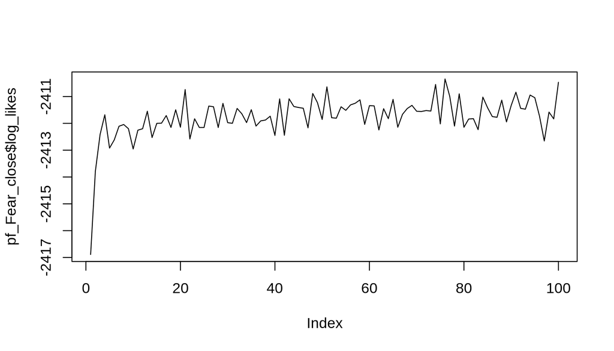

```r
plot(pf_Fear_close$log_likes, type = "l")
```

### Restricted model

The model can be written as in terms of 2 parameters for the state model by writing it as

$$F = \begin{pmatrix}
\theta & 0 \\
0 & \theta
\end{pmatrix}, \quad
Q = \begin{pmatrix}
\exp(2\psi) & 0 \\
0 & \exp(2\psi)
\end{pmatrix}$$

We can estimate the restricted model as follows (see the vignette mentioned in the beginning for details about the arguments to `PF_EM`).

```r
G <- matrix(0, 2^2, 1)
G[1, 1] <- G[4, 1] <- 1
J <- matrix(1, 2, 1)
K <- matrix(nrow = 2 * (2 - 1) / 2, ncol = 0)

pf_Fear_restrict <- PF_EM(
  Surv(tstart, tstop, y) ~ x + ddFixed(x) + ddFixed_intercept(TRUE), df,
  Q_0 = diag(1, 2), G = G, J = J, K = K, theta = .1, psi = 0, phi = numeric(),
  by = 1, type = "VAR", model = "exponential", max_T = n_periods,
  control = PF_control(
    N_fw_n_bw = 500, N_smooth = 2000, N_first = 2000, eps = .001,
    method = "AUX_normal_approx_w_cloud_mean", fix_seed = FALSE,
    n_max = 100, smoother = "Fearnhead_O_N",
    nu = 8, covar_fac = 1.1, n_threads = n_threads))
```

```
## a_0 not supplied. IWLS estimates of static glm model is used for random walk models. Otherwise the values are zero
```

The final estimates are

```r
pf_Fear_restrict$F
```

```
##             (Intercept)     x
## (Intercept)       0.899 0.000
## x                 0.000 0.899
```

```r
show_covar(pf_Fear_restrict$Q)
```

```
## Standard deviations
## (Intercept)           x
##      0.3358      0.3358
## Lower correlation matrix
## [1] 0
```

```r
pf_Fear_restrict$fixed_effects
```

```
## (Intercept)  ddFixed(x)
##      -6.080      -1.403
```

and a log-likelihood approximation is

```r
print(
  logLik(PF_forward_filter(pf_Fear_restrict, N_fw = 20000, N_first = 20000)),
  digits = 7)
```

```
## 'log Lik.' -2413.223 (df=NA)
```

## References

Briers, Mark, Arnaud Doucet, and Simon Maskell. 2009. “Smoothing Algorithms for State–Space Models.” *Annals of the Institute of Statistical Mathematics* 62 (1): 61. doi:10.1007/s10463-009-0236-2.

Cappé, Olivier, Eric Moulines, and Tobias Ryden. 2005. *Inference in Hidden Markov Models (Springer Series in Statistics)*. Berlin, Heidelberg: Springer-Verlag.

Fearnhead, Paul, David Wyncoll, and Jonathan Tawn. 2010. “A Sequential Smoothing Algorithm with Linear Computational Cost.” *Biometrika* 97 (2). [Oxford University Press, Biometrika Trust]: 447–64. http://www.jstor.org/stable/25734097.

Kingma, Diederik P, and Jimmy Ba. 2014. “Adam: A Method for Stochastic Optimization.” *arXiv Preprint arXiv:1412.6980*.

Polyak, Boris T, and Anatoli B Juditsky. 1992. “Acceleration of Stochastic Approximation by Averaging.” *SIAM Journal on Control and Optimization* 30 (4). SIAM: 838–55.

Poyiadjis, George, Arnaud Doucet, and Sumeetpal S. Singh. 2011. “Particle approximations of the score and observed information matrix in state space models with application to parameter estimation.” *Biometrika* 98 (1): 65–80. doi:10.1093/biomet/asq062.